# 基本地圖繪製

B06208030 何承諭

2019年7月15日

> 以下範例使用台南市學校點資料、台北市速食店點位(假資料)與全台行政區資料作圖 [here](https://github.com/lessthan41/SummerCollege_108/tree/master/data)  
> 還有一些推薦的套件們在這裡可以找到 [here](https://cengel.github.io/rspatial/4_Mapping.nb.html)
- 1. 使用套件
- 2. 讀檔
  - 讀.shp檔
  - 讀.csv檔
- 3. 確認投影方式
- 4. 繪製點資料(基本疊圖)
  - 圖資校正
- 範例一：面量圖
  - 前置作業─資料整併
  - 面量圖上色
- 範例二：空間分析函數的應用
  - 前置作業─資料匯入整併
  - 條件篩選
  - 繪製篩選結果
> 1. 環境建置 ── 套件們  
>    GISTools (intersect, buffer, gdistance等相關函數)  
>    rgdal (讀shp)  
>    sp (投影轉換)

> ```r
> library(GISTools)
> library(rgdal)
> library(sp)
> library(dplyr) # 這個非必要
> ```

> back to top
> 2. 讀檔

> 以下讀檔範例 Popn_TWN2.shp, Schools.shp

> ```r
> setwd("C:/Users/smili/Downloads/Spatial_Analysis")
>
> # 讀取.shp檔 shapefile是由很多個檔案(.cpg .shx等等)所組成的
> # 讀檔範例 Popn_TWN2.shp, Schools.shp
> TW <- readOGR(dsn = ".", layer = "Popn_TWN2", encoding="unicode") # 台灣村里界 (面資料)
> Schools <- readOGR(dsn = ".", layer = "Schools", encoding="unicode") # 台南市學校 (點資料)
> TN <- subset(TW, COUNTY == "臺南市") # 選出臺南市
> ```

> 以下讀檔範例 station.csv (經緯度)

> ```r
> setwd("C:/Users/smili/Downloads/Spatial_Analysis")
> file <- read.csv("station.csv")
>
> head(file)
> ```

> ```
> ##     stno         name      Lon     Lat
> ## 1 466850 五分山雷達站 121.7812 25.0712
> ## 2 466880         板橋 121.4420 24.9976
> ## 3 466900         淡水 121.4489 25.1649
> ## 4 466910         鞍部 121.5297 25.1826
> ## 5 466920         臺北 121.5149 25.0377
> ## 6 466930       竹子湖 121.5445 25.1621
> ```

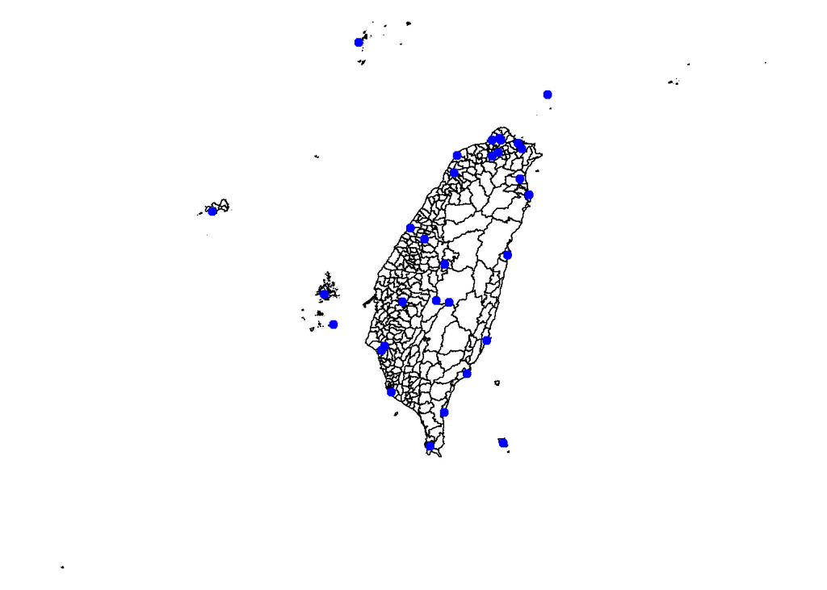

> ```r
> # Case 1: Datum = TWD97, Coor = TM2(m) 如果資料是TM2度XY座標，就直接代入以下公式速解(CRS都幫你設定好了)
> # crs <- CRS("+proj=tmerc +lat_0=0 +lon_0=121 +k=0.9999 +x_0=250000 +y_0=0 +ellps=GRS80 +units=m +no_defs")
> # point = SpatialPointsDataFrame(coords = data.frame(file$X, points$Y),
> #                                data = points@data,
> #                                proj4string = crs)
>
> # Case 2: Datum = TWD97/WGS84, Coor = Lon/Lat 如果你的座標是經緯度，那也是代公式XD
> crs <- CRS("+init=epsg:4326") # proj4string of coords 經緯度的 epsg(座標代碼)
> point <- SpatialPointsDataFrame(coords = data.frame(file$Lon, file$Lat),
>                                 data = file,
>                                 proj4string = crs)
> point <- spTransform(point, TN@proj4string) # 座標轉換
>
> # 測試讀檔是否成功
> par(mar = c(0,0,0,0)) # 設置畫布位置
> plot(TW)
> plot(point, add=T, col = 'blue', cex = 1, pch=19)
> ```

> 不管哪一種方式  
> 讀進來後都會是 SpatialPolygonsDataframe (面) 或 SpatialPointsDataframe (點)  
> 這兩種資料格式內部大致包含了 投影方式(Projection) 幾何資料(Geometry) 屬性資料框(Dataframe)  
> 投影方式在兩個以上的資料堆疊時要一致  
> 幾何資料拿來呈現畫圖(行政區外框)  
> 屬性資料拿來操作(把你要的資料Merge進他的欄位裡用來面量圖著色)

> ```r
> # 屬性資料框 呼叫方式: @data
> data <- TN@data
> head(data)
> ```

> ```
> ##      TOWN_ID   TOWN COUNTY_ID COUNTY A0A14_CNT A0A14_M A0A14_F A15A64_CNT
> ## 327 67000010 新營區     67000 臺南市     10171    5289    4882      55555
> ## 328 67000020 鹽水區     67000 臺南市      2528    1326    1202      18051
> ## 329 67000030 白河區     67000 臺南市      2475    1268    1207      19016
> ## 330 67000040 柳營區     67000 臺南市      1818     960     858      15110
> ## 331 67000050 後壁區     67000 臺南市      1905     988     917      15853
> ## 332 67000060 東山區     67000 臺南市      1779     926     853      14296
> ##     A15A64_M A15A64_F A65UP_CNT A65UP_M A65UP_F INFO_TIME
> ## 327    27681    27874     12132    5565    6567   107Y06M
> ## 328     9716     8335      4908    2258    2650   107Y06M
> ## 329    10322     8694      6803    3201    3602   107Y06M
> ## 330     8110     7000      4343    2034    2309   107Y06M
> ## 331     8530     7323      5774    2712    3062   107Y06M
> ## 332     7921     6375      4867    2269    2598   107Y06M
> ```

> ```r
> # 投影方法 呼叫方式: @proj4string
> TN@proj4string
> ```

> ```
> ## CRS arguments:
> ##  +proj=tmerc +lat_0=0 +lon_0=121 +k=0.9999 +x_0=250000 +y_0=0
> ## +ellps=GRS80 +units=m +no_defs
> ```

> back to top
> 3. 確認投影方式是否相同

> ```r
> # 確認兩者投影方式是否相同
> Schools@proj4string
> ```

> ```
> ## CRS arguments:
> ##  +proj=tmerc +lat_0=0 +lon_0=121 +k=0.9999 +x_0=250000 +y_0=0
> ## +a=6378157.5 +b=6356772.2 +units=m +no_defs
> ```

> ```r
> TN@proj4string
> ```

> ```
> ## CRS arguments:
> ##  +proj=tmerc +lat_0=0 +lon_0=121 +k=0.9999 +x_0=250000 +y_0=0
> ## +ellps=GRS80 +units=m +no_defs
> ```

> ```r
> # 發現疑似投影不相同的情形(橢球體不同)
> Schools <- spTransform(Schools, TN@proj4string) # 把Schools的投影替換為TN的使一致
> ```

> back to top
> 4. 畫出來觀察一下 (疊圖操作)

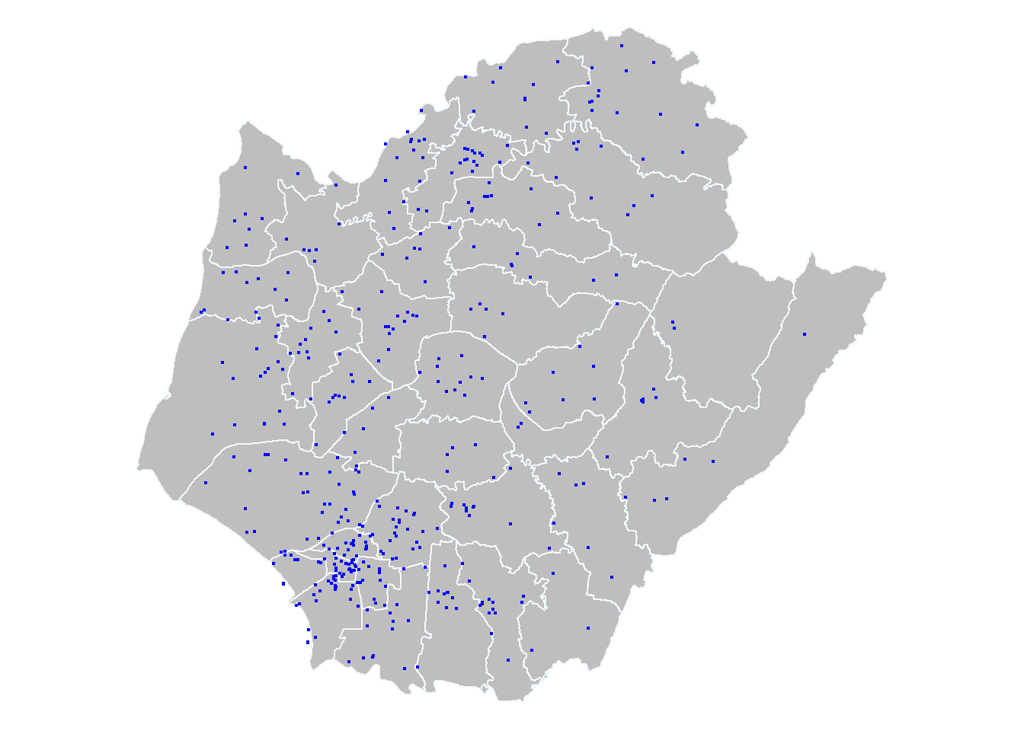

> ```r
> par(mar = c(0,0,0,0)) # 設置畫布位置
> plot(TN, col="grey", border="aliceblue")
> plot(Schools, add=T, pch=19, col="blue", cex=0.3)
> ```

> 圖資校正

> 這裡我們可以發現有些點在邊界外，在確認投影方式相同的情形下一般視為誤差  
> 因此我會選擇進行:

> ```
> 1. 邊緣校正 (此步驟視情形使用)
> 2. 忽略位於縣市界線外的學校 (本次我使用)
> ```

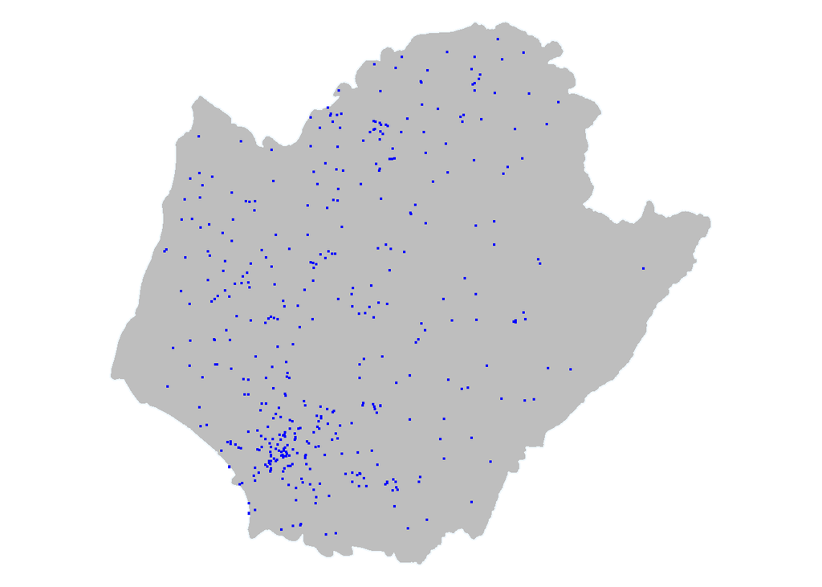

> ```r
> # 1. 邊緣校正
> # 不捨棄點資料，但可能包含到其他行政區的部分點資料
> # 在原本臺南市邊界上做環域擴大原本行政區邊界 單位為投影方式的單位，此處為公尺
> TN.buffer <- gBuffer(TN, width=300)
>
> par(mar = c(0,0,0,0)) # 設置畫布位置
> plot(TN.buffer, col="grey", border="aliceblue")
> plot(Schools, add=T, pch=19, col="blue", cex=0.3)
> ```

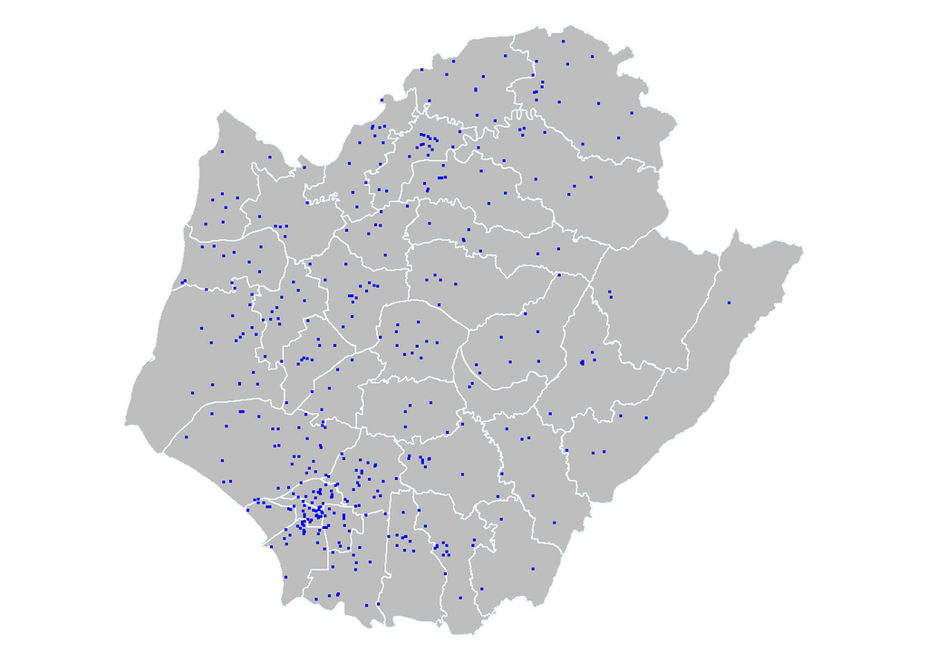

> ```r
> # 2. 忽略界線外的學校 直接取交集
> # 優點就是直覺與直接 乾淨俐落
> # byid 一般取交集都使用TRUE (用在配對兩個資料集之間的id關聯)
> Schools.cor <- gIntersection(TN, Schools, byid = T)
>
> par(mar = c(0,0,0,0)) # 設置畫布位置
> plot(TN, col="grey", border="aliceblue")
> plot(Schools.cor, add=T, pch=19, col="blue", cex=0.3)
> ```

> back to top

## 面量圖 Choropleth

> 把要畫的資料整併進來

> ```r
> # 叫出屬性資料表
> df <- TN@data
>
> # 新增欄位 AREA(km2) poly.areas()求土地面積
> df$AREA <- poly.areas(TN) / 10^6
>
> # 新增欄位 Schools poly.counts()求Schools在每個行政區內的點數總和
> df$Schools <- poly.counts(Schools, TN)
>
> # 計算學校密度
> df$DENSITY <- df$Schools / df$AREA
>
> head(df)
> ```

> ```
> ##      TOWN_ID   TOWN COUNTY_ID COUNTY A0A14_CNT A0A14_M A0A14_F A15A64_CNT
> ## 327 67000010 新營區     67000 臺南市     10171    5289    4882      55555
> ## 328 67000020 鹽水區     67000 臺南市      2528    1326    1202      18051
> ## 329 67000030 白河區     67000 臺南市      2475    1268    1207      19016
> ## 330 67000040 柳營區     67000 臺南市      1818     960     858      15110
> ## 331 67000050 後壁區     67000 臺南市      1905     988     917      15853
> ## 332 67000060 東山區     67000 臺南市      1779     926     853      14296
> ##     A15A64_M A15A64_F A65UP_CNT A65UP_M A65UP_F INFO_TIME      AREA
> ## 327    27681    27874     12132    5565    6567   107Y06M  38.60263
> ## 328     9716     8335      4908    2258    2650   107Y06M  51.58097
> ## 329    10322     8694      6803    3201    3602   107Y06M 128.23901
> ## 330     8110     7000      4343    2034    2309   107Y06M  61.54153
> ## 331     8530     7323      5774    2712    3062   107Y06M  72.41042
> ## 332     7921     6375      4867    2269    2598   107Y06M 124.11432
> ##     Schools    DENSITY
> ## 327      17 0.44038451
> ## 328      13 0.25203094
> ## 329      14 0.10917115
> ## 330      10 0.16249189
> ## 331      11 0.15191184
> ## 332      10 0.08057088
> ```

> back to top

> 面量圖上色

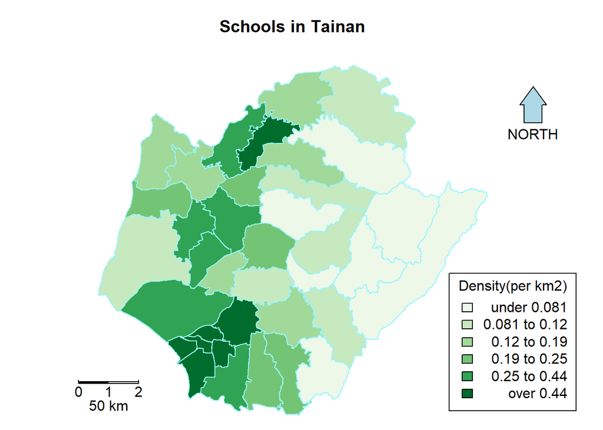

> ```r
> # plot
> par(mar = c(0,0,3,1)) # 調整下左上右邊界
> shades = auto.shading(df$DENSITY,n=6, cols = brewer.pal(6, "Greens")) # 把顏色自動分為6層
> choropleth(TN, df$DENSITY, shading=shades) # 面量圖
> plot(TN, col=rgb(0,0,0,0), add=T, border="cadetblue1") # 只是設邊框顏色，可忽略
> map.scale(152025.1,2537352,10000, "50 km",2,1) # 前面為比例尺的位置設置 可以使用locator()來定位
> north.arrow(222425,2580695,1500,col= 'lightblue') # 指北針
> title('Schools in Tainan') # 標題
> choro.legend(208525.1,2555695, shades, title="Density(per km2)") # 圖例
> ```

> 或者你想要拿算出來的密度去ggplot其他圖表也都可以自行操作

> back to top

## 空間分析函數的應用

> 前置作業─資料匯入整併

> ```r
> # 讀檔
> setwd("C:/Users/smili/Downloads/Spatial_Analysis")
> FF <- readOGR(dsn = ".", layer = "Tpe_Fastfood", encoding="utf8")
> Taipei_Vill <- readOGR(dsn = ".", layer = "Taipei_Vill", encoding="unicode")
> ```

> ```r
> # 確認投影
> FF@proj4string
> ```

> ```
> ## CRS arguments:
> ##  +proj=tmerc +lat_0=0 +lon_0=121 +k=0.9999 +x_0=250000 +y_0=0
> ## +ellps=GRS80 +units=m +no_defs
> ```

> ```r
> Taipei_Vill@proj4string
> ```

> ```
> ## CRS arguments:
> ##  +proj=tmerc +lat_0=0 +lon_0=121 +k=0.9999 +x_0=250000 +y_0=0
> ## +ellps=GRS80 +units=m +no_defs
> ```

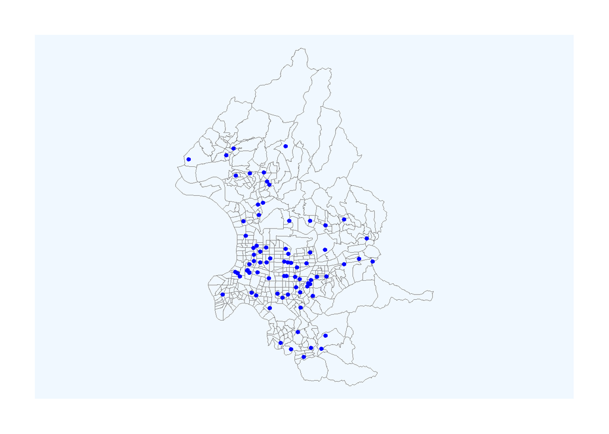

> ```r
> # 資料處理
> FF_MIC = subset(FF, STORE == "MIC") # 取麥當勞
>
> # 觀察資料
> par(mar = c(2,2,2,2))
> plot(Taipei_Vill, lwd = 0.5, border = "grey50", bg='aliceblue')
> plot(FF_MIC, add=T, pch=19, col="blue", cex=0.6)
> ```

> back to top

> 條件篩選

> 找出各村里以中心點圓心，半徑1000m內涵蓋最多麥當勞的村里

> ```r
> # 利用村里邊界找出幾何中心點 gCentroid
> centroids <- gCentroid(Taipei_Vill, byid = T, id = rownames(Taipei_Vill))
>
> # 利用村里中心點找出各村里半徑1000m內有多少麥當勞
> df.tmp <- gWithinDistance(FF_MIC, centroids, byid=T, dist=1000) %>% data.frame()
> df.tmp$SUM <- rowSums(df.tmp) # 計算各行總和 (true / false 相當於 1 / 0)
> head(df.tmp)
> ```

> ```
> ##      X1    X2    X3    X7   X10   X18   X27   X28   X29   X30   X31   X32
> ## 0 FALSE FALSE FALSE FALSE FALSE FALSE FALSE FALSE FALSE FALSE FALSE FALSE
> ## 1 FALSE FALSE FALSE FALSE FALSE FALSE FALSE FALSE FALSE FALSE FALSE FALSE
> ## 2 FALSE FALSE FALSE FALSE FALSE FALSE FALSE FALSE FALSE FALSE FALSE FALSE
> ## 3 FALSE FALSE FALSE FALSE FALSE FALSE  TRUE FALSE FALSE FALSE FALSE FALSE
> ## 4 FALSE FALSE FALSE FALSE FALSE FALSE FALSE FALSE FALSE FALSE FALSE FALSE
> ## 5 FALSE FALSE FALSE FALSE FALSE FALSE  TRUE FALSE FALSE FALSE FALSE FALSE
> ##     X33   X34   X35   X36   X37   X38   X39   X40   X41   X42   X43   X44
> ## 0 FALSE FALSE FALSE FALSE FALSE FALSE FALSE FALSE  TRUE  TRUE FALSE FALSE
> ## 1 FALSE FALSE FALSE FALSE FALSE FALSE FALSE FALSE FALSE  TRUE FALSE FALSE
> ## 2 FALSE FALSE FALSE FALSE FALSE FALSE FALSE FALSE  TRUE  TRUE FALSE FALSE
> ## 3 FALSE FALSE FALSE FALSE FALSE FALSE FALSE FALSE  TRUE  TRUE FALSE FALSE
> ## 4 FALSE FALSE FALSE FALSE FALSE FALSE FALSE FALSE  TRUE FALSE FALSE FALSE
> ## 5 FALSE FALSE FALSE FALSE FALSE FALSE FALSE FALSE FALSE FALSE FALSE FALSE
> ##     X45   X46   X47   X48   X49   X50   X51   X52   X53   X54   X55   X56
> ```
>
> [output cut: 34 more lines]

> ```r
> # 找出總和最大(附近最多麥當勞)的村里是第幾個row 用來當作搜尋村里的index
> index <- c(df.tmp$SUM == max(df.tmp$SUM)) %>% which()
>
> # 要找的那一個村里就可以被搜出來ㄌ 因為她就在行政區圖資的第index行
> toFind_Vill = Taipei_Vill[index,]
>
> # 那圍繞著這個村里的又是哪些麥當勞呢 答案就是在距離 <1000 內的點資料們
> # 這邊一樣可以使用gWithinDistance函數回傳有沒有在1000m內(true/false)
> # 但也可以使用gDistance函數計算距離回傳距離多遠(numeric) 再篩選出距離 <1000m 的row
> index2 <- gDistance(FF_MIC ,gCentroid(toFind_Vill), byid = T) %>% as.vector()
> toFind_MIC <- FF_MIC[index2 <= 1000,]
> ```

> back to top

> 繪製篩選結果

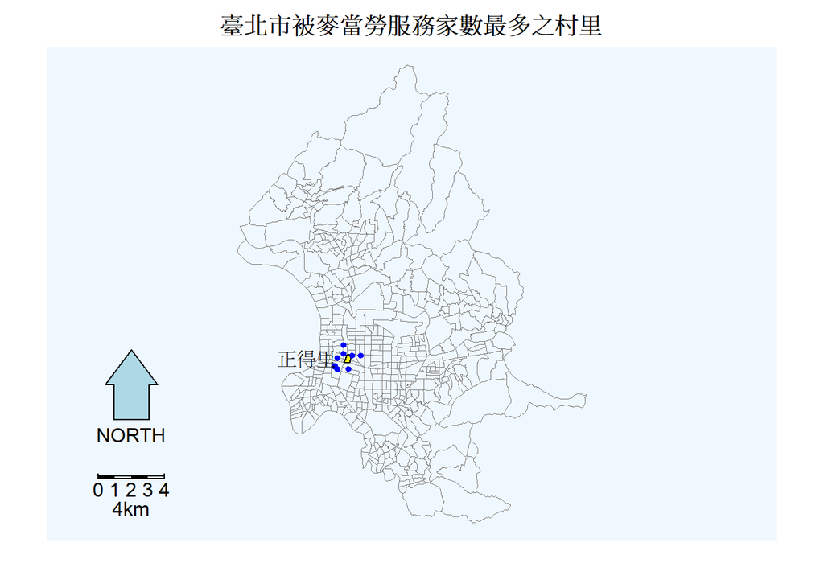

> ```r
> # 接下來就跟之前作法相似 把它畫出來~
> par(mar = c(2,2,2,2))
> plot(Taipei_Vill, lwd = 0.5, border = "grey50", bg='aliceblue')
> plot(toFind_Vill, col="yellow", add=T)
> plot(toFind_MIC, add=T, col="blue", pch=19, cex = 0.6)
> map.scale(289702.6,2764163,4000, "4km", 4, 1) # TWD97, 4000m, 4km
> north.arrow(289702.6,2767730,miles2ft(0.2),col= 'lightblue')
> title("臺北市被麥當勞服務家數最多之村里")
> text(302796.3, 2771416, labels=toFind_Vill$VILLAGE, pos=2)
> ```

> back to top